# College Admissions

Will Doyle

## College Admissions: From the College’s View

All of you have quite recently gone through the stressful process of figuring out which college to attend. You most likely selected colleges you thought might be a good fit, sent off applications, heard back from them, and then weighed your options. Those around you probably emphasized what an important decision this is for you and for your future.

## The College Admissions “Funnel”

The [admissions funnel](https://www.curacubby.com/blog/admissions-funnel) is a well-established metaphor for understanding the enrollment process from the college’s perspective. It begins with colleges identifying prospective students: those who might be interested in enrolling. This proceeds to “interested” students, who engage with the college via registering on the college website, sending test scores, visiting campus, or requesting other information. Some portion of these interested students will then apply. Applicants are then considered, and admissions decisions are made. From this group of admitted students a certain proportion will actually enroll. Here’s live data from UC Santa Cruz (go Banana Slugs!) on their [enrollment funnel](https://iraps.ucsc.edu/iraps-public-dashboards/student-demand/admissions-funnel.html).

Each stage in this process involves modeling and prediction: how can we predict which prospective students will end up being interested students? How many interested students will turn into applicants? And, most importantly, how many admitted students will actually show up in the fall?

Colleges aren’t powerless in this process. Instead, they execute a careful strategy to intervene at each stage to get both the number and type of students they want to convert to the next stage. This is called enrollment management. Why did you receive so many emails, brochures and maybe even text messages? Some model somewhere said that the intervention could convert you from a prospect to an interest, or from an interest to an applicant.

We’re going to focus on the very last step: from admitted students to what’s called a yield: a student who actually shows up and sits down for classes in the fall.

The stakes are large: if too few students show up, then the institutions will not have enough revenues to operate. If too many show up the institution will not have capacity for all of them. On top of this, enrollment managers are also tasked with the combined goals of increasing academic prestige (usually through test scores and GPA) and increasing the socioeconomic diversity of the entering class. As we’ll see, these are not easy tasks. n

## The Data

We’re going to be using a dataset that was constructed to resemble a typical admissions dataset. To be clear: this is not real data, but instead is based on the relationships we see in actual datasets. Using real data in this case would be a violation of privacy.

```r
library(tidyverse)
library(tidymodels)
library(scales)
```

```r
ad<-read_rds("admit_data.Rds")
```

Codebook for admit_data.rds

| Variable Name | Description |
| --- | --- |
| ID | Student id |
| income | Family income (AGI) |
| sat | SAT/ACT score (ACT scores converted to SAT scale) |
| gpa | HS GPA, four point scale |
| visit | Did student visit campus? |
| legacy | Did student parent go to this college? |
| registered | Did student register on the website? |
| sent_scores | Did student send scores prior to applying? |
| distance | Distance from student home address to campus |
| tuition | Stated tuition: $45,000 |
| need_aid | Need-based aid offered |
| merit_aid | Merit-based aid offered |
| net_price | Net Price: Tuition less aid received |
| yield | Student enrolled in classes in fall after admission |

### The Basics

```r
## How many admitted students enroll?
ad%>%summarize(`Yield Rate`=percent(mean(yield)))
```

[output not shown]

```r
## Just for enrolled students
ad%>%filter(yield==1)%>%summarize(
               `Average  SAT Score`=number(mean(sat),accuracy=1,big.mark=""),
               `Average GPA`=number(mean(gpa),accuracy = 1.11),
               `Tuition`=dollar(mean(tuition)),
               `Average Net Price`=dollar(mean(net_price),accuracy = 1 ),
               `Total Tuition Revenues`=dollar(sum(net_price)),
               `Total 1st Year Enrollment`=comma(n(),big.mark=","))
```

[output not shown]

So, a few things stand out right away, all of which are pretty common among private colleges. First, this is a moderately selective institution, with an average GPA of 3.33 (unweighted) and an average SAT of about 1200 (about a 25 on the ACT). The average net price is MUCH less than tuition, indicating that the campus is discounting heavily. Total revenues from tuition are about 30 million.

## The Case

We’ve been hired as the data science team for a liberal arts college [this is a real thing](https://www.fire-engine-red.com/financial-aid-and-student-success/).

The college president and the board of trustees have two strategic goals:

1. Increase the average SAT score to 1300
2. Admit at least 200 more students with incomes less than $50,000

Here’s the rub: they want to do this without allowing tuition revenues to drop below $30 million and without changing the size of the entering class, which should be about 1,500 students (plus or minus 50, nobody minds sleeping in the study lounge, right?).

What we need to do is to figure out which students are most and least likely to enroll. We can then target our financial aid strategy to improve yield rates among certain groups.

This is a well-known problem known as [price discrimination](http://sites.bu.edu/manove-ec101/files/2017/11/VarianHalPriceDiscrimination1989.pdf), which is applied in many industries, including airlines, hotels, and software. The idea is to charge the customers who are most willing/able to pay the most, while charging the customers who are least willing/able to pay the least.

To solve our problem we need to do the following:

1. Come up with a prediction algorithm that accurately establishes the relationship between student characteristics and the probability of attendance
2. Adjust policies in order to target those students who we want to attend, thereby increasing their probability of attendance.

## Current Institutional Policies

Essentially every private college engages heavily in tuition discounting. This has two basic forms: need-based aid and merit-based aid. Need-based aid is provided on the basis of income, typically with some kind of income cap. Merit-based aid is based on demonstrated academic qualifications, again usually with some kind of minimum. Here’s this institution’s current policies.

The institution is currently awarding need-based aid for families making less than $100,0000 on the following formula:

$need_aid=500+(income/1000-100)\*-425$

Translated, this means for every $1,000 the family makes less than $100,000 the student receives an additional 425 dollars. So for a family making $50,000, need-based aid will be $500+(50,000/1000-100)*-425= 500+ (-50*-425)$=$21,750. Need based aid is capped at total tuition.

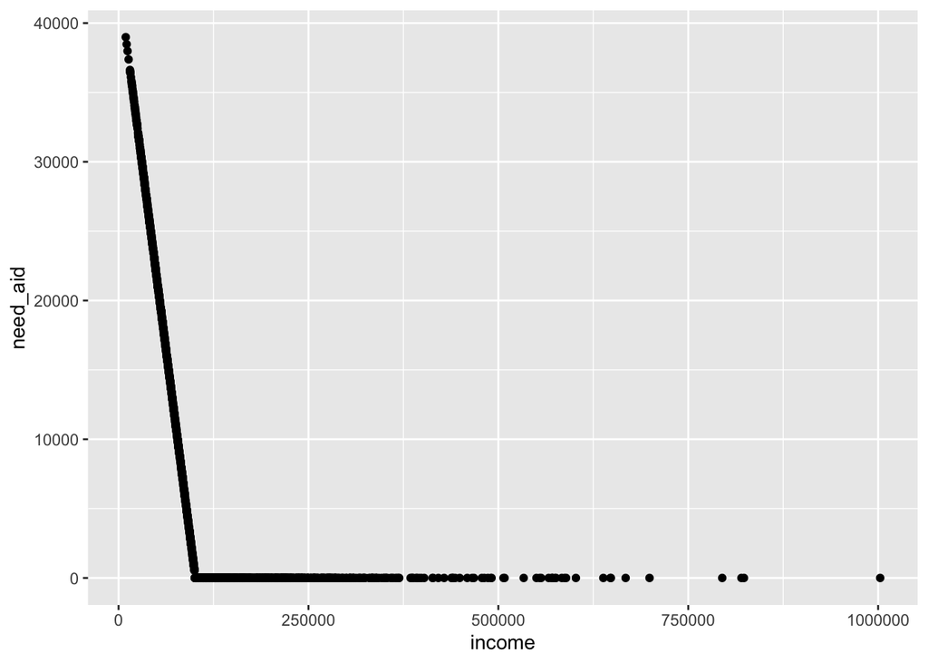

```r
ad%>%
  ggplot(aes(x=income,y=need_aid))+
  geom_point()
```

$merit_aid=500+(sat/10\*250)$

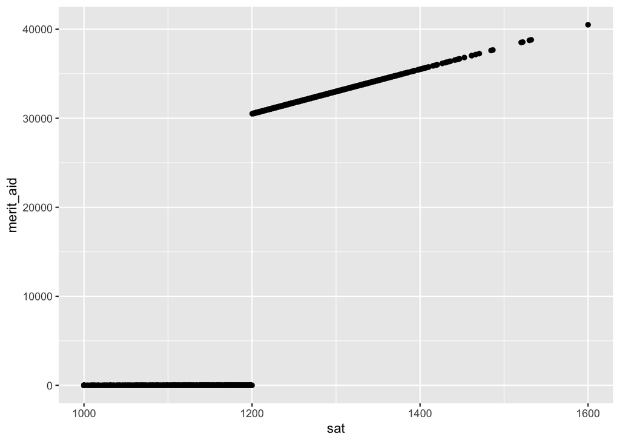

```r
ad%>%
  ggplot(aes(x=sat,y=merit_aid))+
  geom_point()
```

## Classification

Our core prediction problem is [classification](https://towardsdatascience.com/machine-learning-classifiers-a5cc4e1b0623). There are two groups of individuals that constitute our outcome: those who attended and those who did not. In data science, predicting group membership is known as a classification problem. It occurs whenever the outcome is a set of discrete groupings. We’ll be working with the simplest type of classification problem, which has just two groups, but these problems can have multiple groups– essentially categorical variables.

## Probability of Attendance

Remember: the mean of a binary variable is the same thing as the proportion of the sample with that characteristic. So, the mean of `yield` is the same thing as the proportion of admitted students who attend, or the probability of attendance.

```r
ad%>%summarize(pr_attend=mean(yield))
```

[output not shown]

## Conditional Means

Let’s go back to our first algorithm for prediction: conditional means. Let’s start with the variable `legacy` which indicates whether or not the student has a parent who attended the same institution:

```r
ad%>%
  group_by(legacy)%>%
  summarize(pr_attend=mean(yield))
```

```
## # A tibble: 2 × 2
##   legacy pr_attend
##    <dbl>     <dbl>
## 1      0     0.638
## 2      1     0.802
```

That’s a big difference! Legacy students are abut 17 percentage points more likely to yield than non-legacies.

Next, let’s look at SAT scores. This is a continuouos variable, so we need to first break it up into a smaller number of groups. Let’s look at yield rates by quintile of SAT scores among admitted students:

```r
ad%>%
  mutate(sat_quintile=ntile(sat,n=5))%>%
  group_by(sat_quintile)%>%
  summarize(min_sat=min(sat),
  pr_attend=mean(yield))
```

[output not shown]

*Quick Exercise* calculate yield by quintiles of net price: what do you see?

## Combining Conditional Means

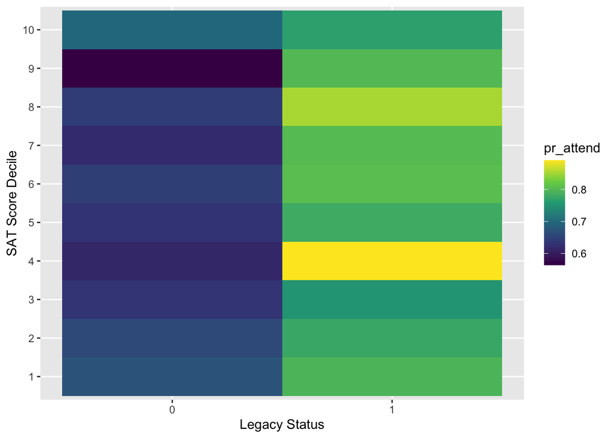

```r
ad%>%
  mutate(sat_quintile=ntile(sat,n=10))%>%
  group_by(sat_quintile,legacy)%>%
  summarize(min_sat=min(sat),
  pr_attend=mean(yield))%>%
  ggplot(aes(y=as_factor(sat_quintile),x=as_factor(legacy),fill=pr_attend))+
  geom_tile()+
  scale_fill_viridis_c()+
  ylab("SAT Score Decile")+xlab("Legacy Status")
```

## Predictions based on conditional means

We can use this simple method to make predictions.

```r
ad<-ad%>%
  mutate(sat_quintile=ntile(sat,n=10))%>%
  group_by(sat_quintile,legacy)%>%
  mutate(prob_attend=mean(yield))%>%
  mutate(pred_attend=ifelse(prob_attend>=.5,1,0))
```

Let’s compare this predicted with the actual:

```r
ad%>%
  group_by(yield,pred_attend)%>%
  summarize(n())%>%
  rename(`Actually Attended`=yield,
         `Predicted to Attend`=pred_attend,
         `Number of Students`=`n()`)
```

```
## # A tibble: 2 × 3
## # Groups:   Actually Attended [2]
##   `Actually Attended` `Predicted to Attend` `Number of Students`
##                 <int>                 <dbl>                <int>
## 1                   0                     1                  674
## 2                   1                     1                 1476
```

## Acccuracy of Conditional Means

```r
ad%>%
  group_by(yield)%>%
  mutate(total_attend=n())%>%
  group_by(yield,pred_attend)%>%
  summarize(n(),`Actual Group`=mean(total_attend))%>%
  mutate(Proportion=`n()`/`Actual Group`)%>%
  rename(`Actually Attended`=yield,
         `Predicted to Attend`=pred_attend,
         `Number of Students`=`n()`)
```

```
## # A tibble: 2 × 5
## # Groups:   Actually Attended [2]
##   `Actually Attend… `Predicted to At… `Number of Stud… `Actual Group` Proportion
##               <int>             <dbl>            <int>          <dbl>      <dbl>
## 1                 0                 1              674            674          1
## 2                 1                 1             1476           1476          1
```

*Question: is this a good model?*

## Prediction via Linear Regression: Wrong, but Useful!

We can use our standard tool of linear regression to build an model and make predictions, with just a few adjustments. This will be wrong, but useful.

We’ll begin as we always do by splitting the data into training and testing datasets.

```r
ad_split<-initial_split(ad)

ad_train<-training(ad_split)

ad_test<-testing(ad_split)
```

We’ll use the wrong model, a linear regression. Running a linear regression with a binary dependent variable is called a linear probability model, which ironically it is not.

```r
lm_mod<-linear_reg()%>%
        set_engine("lm")%>%
        set_mode("regression") ## WRONG
```

We’ll use a formula that includes the variables we’ve used so far,and add that to the recipe.

```r
admit_formula<-as.formula("yield~sat+net_price+legacy")

admit_recipe<-recipe(admit_formula,ad_train)
```

Our workflow will combine the model and recipe:

```r
ad_wf<-workflow()%>%
  add_model(lm_mod)%>%
  add_recipe(admit_recipe)
```

And now we can fit the model to the training data:

```r
ad_wf<-ad_wf%>%
  fit(ad_train)
```

And take a a look at the results:

```r
ad_wf%>%tidy()
```

```
## # A tibble: 4 × 5
##   term          estimate   std.error statistic  p.value
##   <chr>            <dbl>       <dbl>     <dbl>    <dbl>
## 1 (Intercept) -3.01      0.170          -17.7  3.45e-64
## 2 sat          0.00284   0.000132        21.6  1.00e-90
## 3 net_price    0.0000115 0.000000841     13.6  4.57e-40
## 4 legacy       0.132     0.0223           5.93 3.69e- 9
```

*Question: What do we make of these coefficients*

Now we can make predictions based on this model in the testing data.

```r
ad_test<-ad_wf%>%
  predict(ad_test)%>%
  bind_cols(ad_test)
```

Let’s take a look at these predictions

```r
ad_test%>%select(yield,.pred)
```

```
## # A tibble: 538 × 2
##    yield .pred
##    <int> <dbl>
##  1     1 0.897
##  2     1 0.890
##  3     1 1.08
##  4     0 0.539
##  5     1 0.695
##  6     1 1.00
##  7     1 0.678
##  8     1 0.828
##  9     1 0.559
## 10     0 0.468
## # … with 528 more rows
```

So these are probabilities. To complete the classification problem, we need to assign group labels to each case in the testing dataset. Let’s assume that a probability equal to or greater than .5 will be classified as a 1 and everything else as a 0.

```r
ad_test<-ad_test%>%
  mutate(pred_attend=ifelse(.pred>=.5,1,0))

ad_test%>%select(yield,.pred,pred_attend)
```

```
## # A tibble: 538 × 3
##    yield .pred pred_attend
##    <int> <dbl>       <dbl>
##  1     1 0.897           1
##  2     1 0.890           1
##  3     1 1.08            1
##  4     0 0.539           1
##  5     1 0.695           1
##  6     1 1.00            1
##  7     1 0.678           1
##  8     1 0.828           1
##  9     1 0.559           1
## 10     0 0.468           0
## # … with 528 more rows
```

Here’s the problem with using a linear regression in this case: there’s no guarantee that the results will be on the probability scale. So, we can find cases where our model predicted probabilities below 0 or above 1. Of course, these just get labeled as 1 or 0.

```r
ad_test%>%
  filter(.pred>1|.pred<0)%>%
  select(yield,.pred,pred_attend)
```

```
## # A tibble: 39 × 3
##    yield .pred pred_attend
##    <int> <dbl>       <dbl>
##  1     1  1.08           1
##  2     1  1.00           1
##  3     1  1.02           1
##  4     1  1.03           1
##  5     1  1.08           1
##  6     0  1.01           1
##  7     1  1.28           1
##  8     1  1.01           1
##  9     1  1.15           1
## 10     1  1.03           1
## # … with 29 more rows
```

## Accuracy of Linear Regression

```r
ad_test%>%
  group_by(yield)%>%
  mutate(total_attend=n())%>%
  group_by(yield,pred_attend)%>%
  summarize(n(),`Actual Group`=mean(total_attend))%>%
  mutate(Proportion=`n()`/`Actual Group`)%>%
  rename(`Actually Attended`=yield,
         `Predicted to Attend`=pred_attend,
         `Number of Students`=`n()`)
```

```
## # A tibble: 4 × 5
## # Groups:   Actually Attended [2]
##   `Actually Attend… `Predicted to At… `Number of Stud… `Actual Group` Proportion
##               <int>             <dbl>            <int>          <dbl>      <dbl>
## 1                 0                 0               68            163     0.417
## 2                 0                 1               95            163     0.583
## 3                 1                 0               34            375     0.0907
## 4                 1                 1              341            375     0.909
```

### Sensitivity

In the above table, the percent of 1s correctly identified is a measure known as sensitivity:

```r
ad_test%>%
  sensitivity(truth=as.factor(yield),
              estimate=as.factor(pred_attend),
              event_level="second")
```

```
## # A tibble: 1 × 3
##   .metric .estimator .estimate
##   <chr>   <chr>          <dbl>
## 1 sens    binary         0.909
```

### Specficity

The percent of 0s correctly identified is a measure know as specificity

```r
ad_test%>%
  spec(truth=as.factor(yield),
       estimate=as.factor(pred_attend),
       event_level="second")
```

```
## # A tibble: 1 × 3
##   .metric .estimator .estimate
##   <chr>   <chr>          <dbl>
## 1 spec    binary         0.417
```

### Accuracy

```r
ad_test%>%
  accuracy(truth=as.factor(yield),
              estimate=as.factor(pred_attend),
              event_level="second")
```

```
## # A tibble: 1 × 3
##   .metric  .estimator .estimate
##   <chr>    <chr>          <dbl>
## 1 accuracy binary         0.760
```

## Next steps

Now we need to move forward with improving the model and then thinking about policy changes. If we changed elements that the college can control, what would happen?